# StandardError

So for $E(Y^2)$, we integrate over K, where Z is the random variable with $P(Z=k)=\tilde\pi_{k}$:

$E(Y_{r}^2)=E(E(Y_{r}^2|Z)$

$=\sum_{k}$ $\tilde\pi_{k}[U_{kr}+\mu_{kr}^2]$

So $Var(Y_{r})$ = $\sum_{k}$ $\tilde\pi_{k}[U_{kr}+\mu_{kr}^2]$ - $(\sum_k \tilde\pi_{k} \mu_{kr})^2$

Let’s check our calculations for a given tissue:

```r
marginal.var=read.table("../../Dropbox/Aug12/Aug13withEDmarginal.var.txt")[,-1]
#r=sample(seq(1:44),1)
r=38
pi.kl=post.weights


sum.test.part.one=post.weights*(all.arrays$post.covs[,r]+all.arrays$post.means[,r]^2)

##the majority (53% of wiehgt at componenet 1073)
####show example
diag(U.gp1kl)[r] ##less than 1
```

```
## [1] 0.963171
```

```r
mu.gp1kl[r]^2
```

```
## [1] 23.45535
```

```r
part.one.at.k=post.weights[k]*(all.arrays$post.covs[k,r]+all.arrays$post.means[k,r]^2)

mu.2.atk=(post.weights[k]*all.arrays$post.means[k,r])^2


sum.test.e.y.2.r=(post.weights*all.arrays$post.means[,r])

sum(sum.test.part.one)-sum(sum.test.e.y.2.r)^2
```

```
## [1] 5.83046
```

```r
part.one.r=post.weights%*%(all.arrays$post.covs[,r]+all.arrays$post.means[,r]^2)
e.y.2.r=(post.weights%*%(all.arrays$post.means[,r]))^2
part.one.r-e.y.2.r
```

```
##         [,1]
## [1,] 5.83046
```

```r
marginal.var[j,r]
```

```
## [1] 5.83046
```

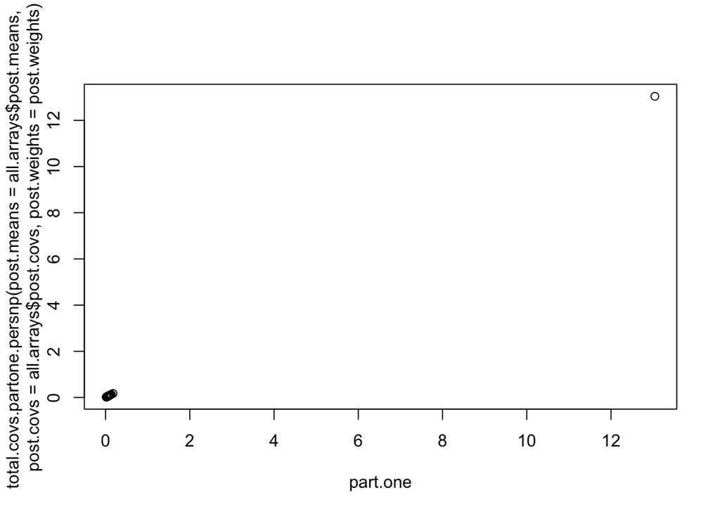

```r
##test for individula component
k=which.max(post.weights)


###show function correct for the first part acorss all tissues
part.one=post.weights%*%(all.arrays$post.covs+all.arrays$post.means^2)


plot(part.one,total.covs.partone.persnp(post.means = all.arrays$post.means,post.covs = all.arrays$post.covs,post.weights = post.weights))
```

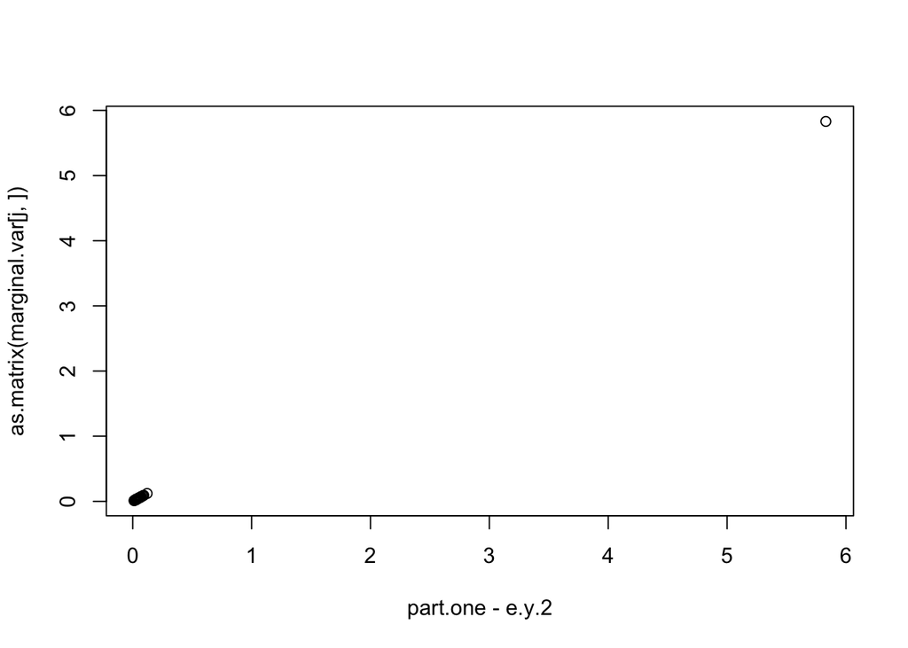

```r
####and check across all check with marginal variance computation##
e.y.2=(post.weights%*%(all.arrays$post.means))^2

plot(part.one-e.y.2,as.matrix(marginal.var[j,]))
```

```r
part.one.tim=function(post.weights,post.covs){
  post.weights%*%post.covs
}

part.two.tim=function(post.weights,post.means,tissue){
  r=tissue
  grand.mean=post.weights%*%post.means
  post.weights%*%((post.means[,r]-grand.mean[r])^2)
}


b.test=read.table("../Data/maxz.txt")
se.test=b.test/b.test

j=14608
r=38
k=1073

j=100
r=10

cov=readRDS("../Data/covmatAug13withED.rds")
pis=readRDS("../Data/pisAug13withED.rds")$pihat

all.arrays=post.array.per.snp(j=j,covmat = cov,b.gp.hat = b.test,se.gp.hat = se.test)

b.mle=as.vector(t(b.test[j,]))##turn i into a R x 1 vector
V.gp.hat=diag(se.test[j,])^2
V.gp.hat.inv <- solve(V.gp.hat)

log.lik.snp=log.lik.func(b.mle,V.gp.hat,cov)
log.lik.minus.max=log.lik.snp-max(log.lik.snp)
#log.pi=log(pis)
#s=log.lik.minus.max+log.pi
exp.vec=exp(log.lik.minus.max)
post.weights=t(exp.vec*pis/sum(exp.vec*pis))

part.one.tim(post.weights = post.weights,post.covs = all.arrays$post.covs)[r]
```

```
## [1] 0.493777
```

```r
part.two.tim(post.weights = post.weights,post.means = all.arrays$post.means,tissue = r)
```

```
##             [,1]
## [1,] 7.22546e-05
```

```r
part.one.tim(post.weights = post.weights,post.covs = all.arrays$post.covs)[r]+part.two.tim(post.weights = post.weights,post.means = all.arrays$post.means,tissue = r)
```

```
##           [,1]
## [1,] 0.4938492
```

```r
total.covs.partone.persnp(all.arrays$post.means,all.arrays$post.covs,post.weights)[r]-((post.weights%*%all.arrays$post.means)^2)[r]
```

```
## [1] 0.4938492
```

Now we look at the median poserior variances:

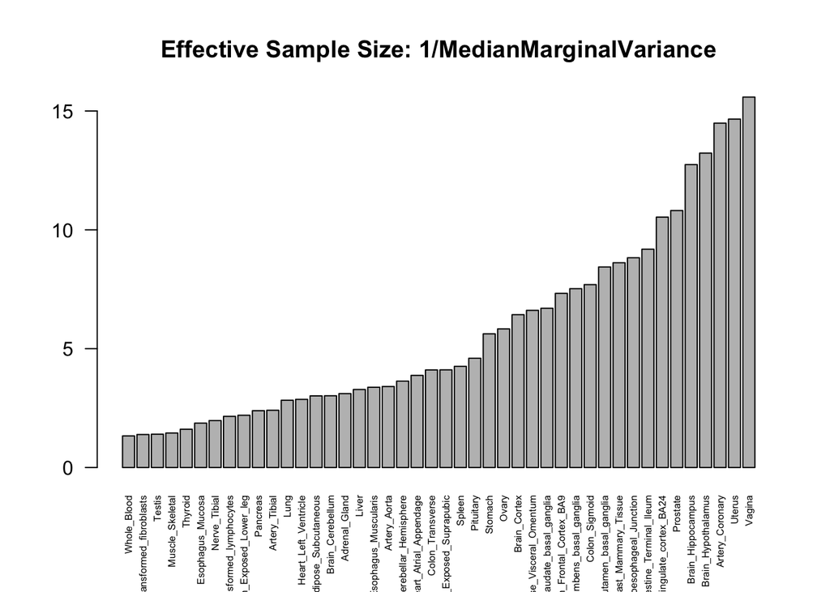

```r
median.mar.var=apply(marginal.var,2,median)
barplot(sort(1/median.mar.var,decreasing=F),cex.names=0.5,main="Effective Sample Size: 1/MedianMarginalVariance",names=colnames(maxz)[order(1/median.mar.var,decreasing=F)],las=2)
```

Now let’s plot effective sample size. Recall:

$n_{jeff}=\frac{s_{j}^2}{\tilde{s_{j}^2}}$

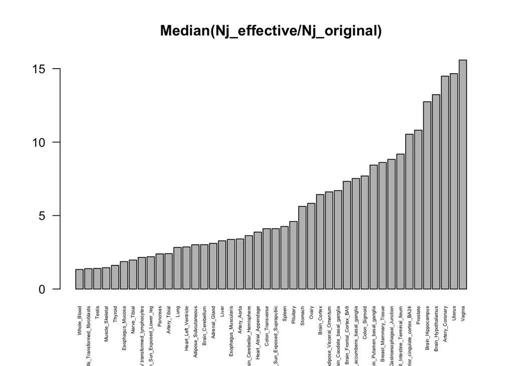

```r
#original.var=as.matrix(standard.error.from.z)^2
original.var=standard.error.from.z/standard.error.from.z
size=as.matrix(exp.sort)
post.var=as.matrix(marginal.var)#*standard.error.from.z^2
njeffective=size*original.var/post.var


##ask why some of the origianl variancres are smaller than posterior variances, even though calculations are right (e.g. 16012, 44)
###15093  44
increase=njeffective/size


barplot(sort(apply(increase,2,median),decreasing=F),las=2,cex.names=0.4)
title("Median(Nj_effective/Nj_original)")
```

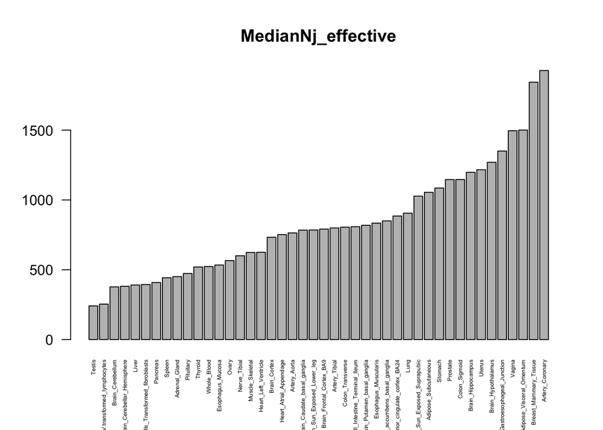

```r
barplot(sort(apply(njeffective,2,median),decreasing=F),cex.names=0.4,las=2)
title("MedianNj_effective")
```

```r
j=10000
b.mle=as.vector(t(b.test[j,]))##turn i into a R x 1 vector
se.test=b.test/b.test

V.gp.hat=diag(se.test[j,])^2
V.gp.hat.inv <- solve(V.gp.hat)
all.arrays=post.array.per.snp(j=j,covmat = cov,b.gp.hat = b.test,se.gp.hat = se.test)

log.lik.snp=log.lik.func(b.mle,V.gp.hat,cov)
log.lik.minus.max=log.lik.snp-max(log.lik.snp)
#log.pi=log(pis)
#s=log.lik.minus.max+log.pi
exp.vec=exp(log.lik.minus.max)
post.weights=t(exp.vec*pis/sum(exp.vec*pis))


v1=post.weights%*%all.arrays$post.covs+post.weights%*%(t(apply((all.arrays$post.means),1,'-',(post.weights%*%all.arrays$post.means)))^2)

v2=post.weights%*%(all.arrays$post.covs+all.arrays$post.means^2)-(post.weights%*%all.arrays$post.means)^2
```